# SYDE 556: Simulating Neurobiological Systems

# Assignment 2: Spiking Neurons

**Author:** *Jonathan Johnston*

**Course Instructor:** *Professor C. Eliasmith*

This assignment details implementation of neuron models for representing temporal stimuli.

The assignment corresponds to the document hosted at:

http://nbviewer.ipython.org/github/celiasmith/syde556/blob/master/Assignment%202.ipynb

## Section 1: Generating a Random Input Signal

### Section 1.1: Gaissuan White Noise

#### Part A

Plot three randomly generated signals of frequency 5, 10, and 20 Hertz.

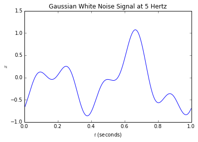

```
RMS: 0.5
```

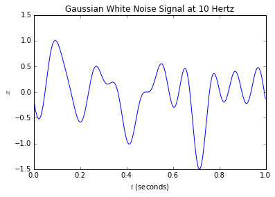

```
RMS: 0.5
```

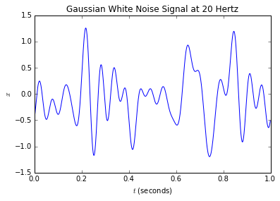

```
RMS: 0.5
```

#### Part B

Now we take 100 different seeds, generate 100 different signals, and average out the signals at each frequency by using the norm.

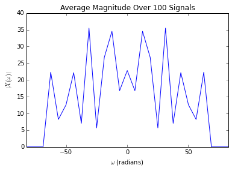

### Section 1.2: Gaussian Power Spectrum Noise

#### Part A

Plot three randomly generated signals of frequency 5, 10, and 20 Hertz; however this time we use a signal generated with a frequency dropoff bandwidth.

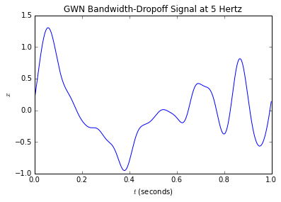

```
RMS: 0.5
```

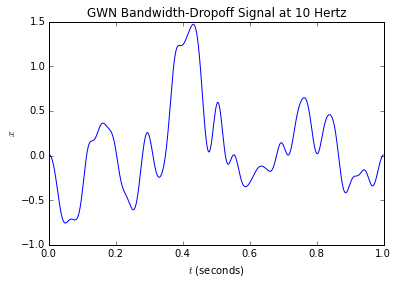

```
RMS: 0.5
```

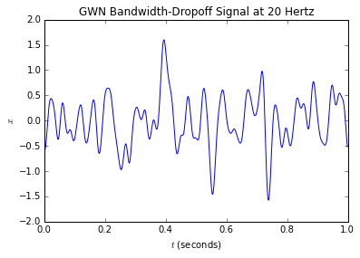

```
RMS: 0.5
```

#### Part B

Now we take 100 different seeds, generate 100 different signals, and average out the signals at each frequency by using the norm; however this time we use the signal generated with a frequency dropoff bandwidth.

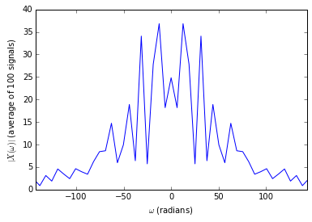

## Section 2: Simulating a Spiking Neuron

#### Part A

```
Number of spikes: 40
```

```
Number of spikes: 143
```

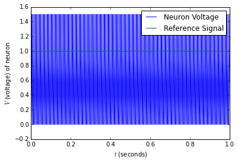

#### Part B

Number of spikes observed is exact for the x = 0 case (40 spikes in 1 second); however the x = 1 case is limited to 143 spikes in 1 second, which is short of its theoretical 150 Hz rate at x = 1. In this simulation we used a time step of 0.001 seconds; however if we decrease this to a smaller time step, say by a factor of 10 to 0.0001 seconds, then we see the spike rate jump to 149 spikes in 1 second for the reference signal of x = 1. Further, another decrease in time step magnitude by a factor of 10 results in 150 Hz neuron activity for x = 1. This implies that the "clock speed" of our simulation, which we modify to approach continuous time, is a limiting factor in accurately simulating neuronal activity.

#### Part C

Now we generate a signal using the Gaussian white noise distribution as in previous sections, generate the spikes using said signal, then overlay them both together.

```
Number of spikes: 50
```

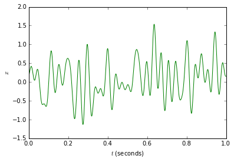

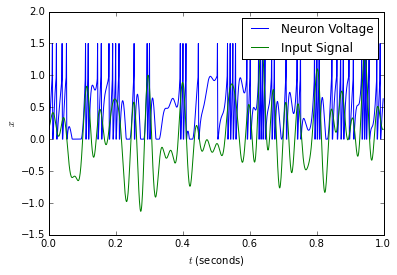

#### Part D

Now we take a closer look at the signal and spikes from Part C.

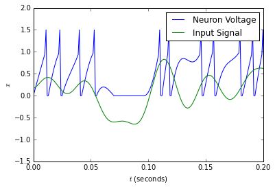

#### Part E

The first obvious method for improving the accuracy of the spiking neuron simulation is to use a more accurate method for approximation beyond Euler's method. Examples of this includes Runge-Kutta and Heun's method.

The next method for improving the accuracy of the spiking neuron simulation is to make the refractory period more accurate. In these areas, interpolation may be used in order to better approximate the next step's value if the time steps do not align well with the refractory periods.

In this assignment these possible improvements have not been implemented.

## Section 3: Simulating Two Spiking Neurons

#### Part A

Simulation of two spiking neurons of opposing encoders at x = 0.

```
Number of spikes for neuron with encoder=(1): 40
```

```
Number of spikes for neuron with encoder=(-1): 40
```

#### Part B

Spiking output of two spiking neurons with opposing encoders at x = 1.

```
Number of spikes for neuron with encoder=(1): 143
```

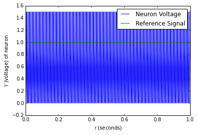

```
Number of spikes for neuron with encoder=(-1): 0
```

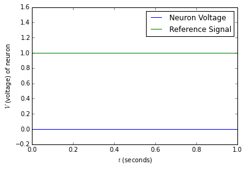

#### Part C

Stimulate the two spiking neurons with a simple sine wave at 5 Hz.

```
Number of spikes for neuron with encoder=(1): 40
```

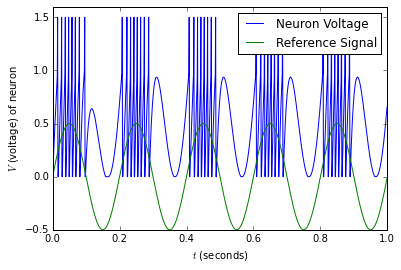

```
Number of spikes for neuron with encoder=(-1): 40
```

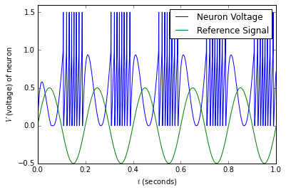

#### Part D

Simulate the two spiking neurons using a Gaussian white noise-generated signal of max frequency 5 Hz.

```
Number of spikes for neuron with encoder=(1): 114
```

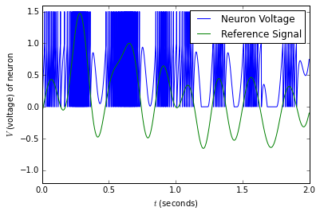

```
Number of spikes for neuron with encoder=(-1): 65
```

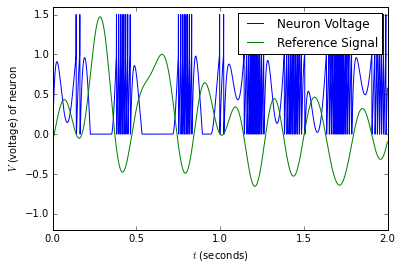

## Section 4: Computing an Optimal Filter

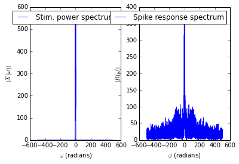

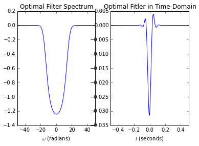

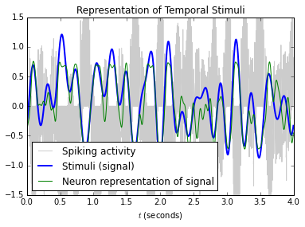